# EnsembleProject

```python
import pandas as pd
import numpy as np
import matplotlib.pyplot as plt
import seaborn as sns
from sklearn.model_selection import train_test_split
from sklearn.preprocessing import StandardScaler
from sklearn.tree import DecisionTreeClassifier
from sklearn.model_selection import GridSearchCV
from sklearn import metrics
from sklearn.ensemble import RandomForestClassifier
from sklearn.metrics import confusion_matrix
from sklearn.ensemble import RandomForestRegressor
from sklearn.model_selection import RandomizedSearchCV
from sklearn.ensemble import AdaBoostClassifier
from sklearn.ensemble import GradientBoostingClassifier
```

**Data Understanding & Exploration: [5 Marks]**

A. Read ‘TelcomCustomer-Churn_1.csv’ as a DataFrame and assign it to a variable. [1 Mark]

B. Read ‘TelcomCustomer-Churn_2.csv’ as a DataFrame and assign it to a variable. [1 Mark]

C. Merge both the DataFrames on key ‘customerID’ to form a single DataFrame [2 Mark]

D. Verify if all the columns are incorporated in the merged DataFrame by using simple comparison Operator in Python. [1 Marks]

**1 a. Read ‘TelcomCustomer-Churn_1.csv’ as a DataFrame and assign it to a variable**

```python
data1 = pd.read_csv("C:/Users/rethi/Desktop/Great Learning/Ensemble/TelcomCustomer-Churn_1.csv")
```

**1 b.Read ‘TelcomCustomer-Churn_2.csv’ as a DataFrame and assign it to a variable**

```python
data2 = pd.read_csv("C:/Users/rethi/Desktop/Great Learning/Ensemble/TelcomCustomer-Churn_2.csv")
```

**1 c.Merge both the DataFrames on key ‘customerID’ to form a single DataFrame**

```python
data1.head()
```

|  | customerID | gender | SeniorCitizen | Partner | Dependents | tenure | PhoneService | MultipleLines | InternetService | OnlineSecurity |
| --- | --- | --- | --- | --- | --- | --- | --- | --- | --- | --- |
| 0 | 7590-VHVEG | Female | 0 | Yes | No | 1 | No | No phone service | DSL | No |
| 1 | 5575-GNVDE | Male | 0 | No | No | 34 | Yes | No | DSL | Yes |
| 2 | 3668-QPYBK | Male | 0 | No | No | 2 | Yes | No | DSL | Yes |
| 3 | 7795-CFOCW | Male | 0 | No | No | 45 | No | No phone service | DSL | Yes |
| 4 | 9237-HQITU | Female | 0 | No | No | 2 | Yes | No | Fiber optic | No |

```python
data2.head()
```

|  | customerID | OnlineBackup | DeviceProtection | TechSupport | StreamingTV | StreamingMovies | Contract | PaperlessBilling | PaymentMethod | MonthlyCharges | TotalCharges | Churn |
| --- | --- | --- | --- | --- | --- | --- | --- | --- | --- | --- | --- | --- |
| 0 | 7590-VHVEG | Yes | No | No | No | No | Month-to-month | Yes | Electronic check | 29.85 | 29.85 | No |
| 1 | 5575-GNVDE | No | Yes | No | No | No | One year | No | Mailed check | 56.95 | 1889.5 | No |
| 2 | 3668-QPYBK | Yes | No | No | No | No | Month-to-month | Yes | Mailed check | 53.85 | 108.15 | Yes |
| 3 | 7795-CFOCW | No | Yes | Yes | No | No | One year | No | Bank transfer (automatic) | 42.30 | 1840.75 | No |
| 4 | 9237-HQITU | No | No | No | No | No | Month-to-month | Yes | Electronic check | 70.70 | 151.65 | Yes |

```python
data = pd.merge(data1, data2, on='customerID')
```

```python
data.head()
```

|  | customerID | gender | SeniorCitizen | Partner | Dependents | tenure | PhoneService | MultipleLines | InternetService | OnlineSecurity | ... | DeviceProtection | TechSupport | StreamingTV | StreamingMovies | Contract | PaperlessBilling | PaymentMethod | MonthlyCharges | TotalCharges | Churn |
| --- | --- | --- | --- | --- | --- | --- | --- | --- | --- | --- | --- | --- | --- | --- | --- | --- | --- | --- | --- | --- | --- |
| 0 | 7590-VHVEG | Female | 0 | Yes | No | 1 | No | No phone service | DSL | No | ... | No | No | No | No | Month-to-month | Yes | Electronic check | 29.85 | 29.85 | No |
| 1 | 5575-GNVDE | Male | 0 | No | No | 34 | Yes | No | DSL | Yes | ... | Yes | No | No | No | One year | No | Mailed check | 56.95 | 1889.5 | No |
| 2 | 3668-QPYBK | Male | 0 | No | No | 2 | Yes | No | DSL | Yes | ... | No | No | No | No | Month-to-month | Yes | Mailed check | 53.85 | 108.15 | Yes |
| 3 | 7795-CFOCW | Male | 0 | No | No | 45 | No | No phone service | DSL | Yes | ... | Yes | Yes | No | No | One year | No | Bank transfer (automatic) | 42.30 | 1840.75 | No |
| 4 | 9237-HQITU | Female | 0 | No | No | 2 | Yes | No | Fiber optic | No | ... | No | No | No | No | Month-to-month | Yes | Electronic check | 70.70 | 151.65 | Yes |

5 rows × 21 columns

**1 d.Verify if all the columns are incorporated in the merged DataFrame by using simple comparisonOperator in Python**

```python
data1_col = data1.columns
data2_col = data.columns
data_col = data.columns
```

```python
#data1 columns plus data2 columns
cols =  set(data1_col.append(data2_col))
```

```python
#merged columns
data_col = set(data_col)
```

```python
#comparining all columns from data1 and data2 are incorporated in merged dataframe
cols == data_col
```

```
True
```

**2 a Impute missing/unexpected values in the DataFrame**

```python
data.head()
```

|  | customerID | gender | SeniorCitizen | Partner | Dependents | tenure | PhoneService | MultipleLines | InternetService | OnlineSecurity | ... | DeviceProtection | TechSupport | StreamingTV | StreamingMovies | Contract | PaperlessBilling | PaymentMethod | MonthlyCharges | TotalCharges | Churn |
| --- | --- | --- | --- | --- | --- | --- | --- | --- | --- | --- | --- | --- | --- | --- | --- | --- | --- | --- | --- | --- | --- |
| 0 | 7590-VHVEG | Female | 0 | Yes | No | 1 | No | No phone service | DSL | No | ... | No | No | No | No | Month-to-month | Yes | Electronic check | 29.85 | 29.85 | No |
| 1 | 5575-GNVDE | Male | 0 | No | No | 34 | Yes | No | DSL | Yes | ... | Yes | No | No | No | One year | No | Mailed check | 56.95 | 1889.5 | No |
| 2 | 3668-QPYBK | Male | 0 | No | No | 2 | Yes | No | DSL | Yes | ... | No | No | No | No | Month-to-month | Yes | Mailed check | 53.85 | 108.15 | Yes |
| 3 | 7795-CFOCW | Male | 0 | No | No | 45 | No | No phone service | DSL | Yes | ... | Yes | Yes | No | No | One year | No | Bank transfer (automatic) | 42.30 | 1840.75 | No |
| 4 | 9237-HQITU | Female | 0 | No | No | 2 | Yes | No | Fiber optic | No | ... | No | No | No | No | Month-to-month | Yes | Electronic check | 70.70 | 151.65 | Yes |

5 rows × 21 columns

```python
data.isnull().sum()
```

```
customerID          0
gender              0
SeniorCitizen       0
Partner             0
Dependents          0
tenure              0
PhoneService        0
MultipleLines       0
InternetService     0
OnlineSecurity      0
OnlineBackup        0
DeviceProtection    0
TechSupport         0
StreamingTV         0
StreamingMovies     0
Contract            0
PaperlessBilling    0
PaymentMethod       0
MonthlyCharges      0
TotalCharges        0
Churn               0
dtype: int64
```

```python
for i in data.columns:
    print(i)
    print(data[i].unique())
    print()
```

```
customerID
['7590-VHVEG' '5575-GNVDE' '3668-QPYBK' ... '4801-JZAZL' '8361-LTMKD'
 '3186-AJIEK']

gender
['Female' 'Male']

SeniorCitizen
[0 1]

Partner
['Yes' 'No']

Dependents
['No' 'Yes']

tenure
[ 1 34  2 45  8 22 10 28 62 13 16 58 49 25 69 52 71 21 12 30 47 72 17 27
  5 46 11 70 63 43 15 60 18 66  9  3 31 50 64 56  7 42 35 48 29 65 38 68
 32 55 37 36 41  6  4 33 67 23 57 61 14 20 53 40 59 24 44 19 54 51 26  0
 39]

PhoneService
['No' 'Yes']

MultipleLines
['No phone service' 'No' 'Yes']

InternetService
['DSL' 'Fiber optic' 'No']

OnlineSecurity
['No' 'Yes' 'No internet service']

OnlineBackup
['Yes' 'No' 'No internet service']

DeviceProtection
['No' 'Yes' 'No internet service']

```

[output cut: 12 more lines]

```
PaperlessBilling
['Yes' 'No']

PaymentMethod
['Electronic check' 'Mailed check' 'Bank transfer (automatic)'
 'Credit card (automatic)']

MonthlyCharges
[29.85 56.95 53.85 ... 63.1  44.2  78.7 ]

TotalCharges
['29.85' '1889.5' '108.15' ... '346.45' '306.6' '6844.5']

Churn
['No' 'Yes']
```

```python
sorted(data["TotalCharges"].unique())
```

```
[' ',
 '100.2',
 '100.25',
 '100.35',
 '100.4',
 '100.8',
 '100.9',
 '1001.2',
 '1001.5',
 '1003.05',
 '1004.35',
 '1004.5',
 '1004.75',
 '1005.7',
 '1006.9',
 '1007.8',
 '1007.9',
 '1008.55',
 '1008.7',
 '1009.25',
 '101.1',
 '101.45',
 '101.65',
 '101.9',
 '1010',
 '1011.05',
 '1011.5',
 '1011.8',
 '1012.4',
 '1013.05',
 '1013.2',
 '1013.35',
 '1013.6',
 '1014.25',
 '1016.7',
 '1017.35',
 '102.45',
 '102.5',
 '102.75',
 '1020.2',
```

[output cut: 946 more lines]

```
 '155.35',
 '155.65',
 '155.8',
 '155.9',
 '1551.6',
 '1553.2',
 '1553.9',
 '1553.95',
 '1554',
 '1554.9',
 '1555.65',
 '1556.85',
 '1558.65',
 '1558.7',
 ...]
```

```python
numeric_values = pd.to_numeric(data['TotalCharges'], errors='coerce').dropna()
median_value = np.median(numeric_values)
data['TotalCharges'] = pd.to_numeric(data['TotalCharges'], errors='coerce').fillna(median_value)
```

Used median value (we can use this for normal and skewed distribution) to impute Total charger blanks

```python
sorted(data["TotalCharges"].unique())
```

```
[18.8,
 18.85,
 18.9,
 19.0,
 19.05,
 19.1,
 19.15,
 19.2,
 19.25,
 19.3,
 19.4,
 19.45,
 19.5,
 19.55,
 19.6,
 19.65,
 19.7,
 19.75,
 19.8,
 19.85,
 19.9,
 19.95,
 20.0,
 20.05,
 20.1,
 20.15,
 20.2,
 20.25,
 20.3,
 20.35,
 20.4,
 20.45,
 20.5,
 20.55,
 20.6,
 20.65,
 20.7,
 20.75,
 20.8,
 20.85,
```

[output cut: 946 more lines]

```
 244.75,
 244.8,
 244.85,
 245.15,
 245.2,
 246.25,
 246.3,
 246.5,
 246.6,
 246.7,
 247.0,
 247.25,
 248.4,
 248.95,
 ...]
```

'Total Charges' column is cleaned

**2 B. Make sure all the variables with continuous values are of ‘Float’ type. [2 Marks] [For Example: MonthlyCharges, TotalCharges]**

```python
data.info()
```

```
<class 'pandas.core.frame.DataFrame'>
Int64Index: 7043 entries, 0 to 7042
Data columns (total 21 columns):
 #   Column            Non-Null Count  Dtype
---  ------            --------------  -----
 0   customerID        7043 non-null   object
 1   gender            7043 non-null   object
 2   SeniorCitizen     7043 non-null   int64
 3   Partner           7043 non-null   object
 4   Dependents        7043 non-null   object
 5   tenure            7043 non-null   int64
 6   PhoneService      7043 non-null   object
 7   MultipleLines     7043 non-null   object
 8   InternetService   7043 non-null   object
 9   OnlineSecurity    7043 non-null   object
 10  OnlineBackup      7043 non-null   object
 11  DeviceProtection  7043 non-null   object
 12  TechSupport       7043 non-null   object
 13  StreamingTV       7043 non-null   object
 14  StreamingMovies   7043 non-null   object
 15  Contract          7043 non-null   object
 16  PaperlessBilling  7043 non-null   object
 17  PaymentMethod     7043 non-null   object
 18  MonthlyCharges    7043 non-null   float64
 19  TotalCharges      7043 non-null   float64
 20  Churn             7043 non-null   object
dtypes: float64(2), int64(2), object(17)
memory usage: 1.2+ MB
```

```python
data["SeniorCitizen"] = data["SeniorCitizen"].astype(object)
```

**All continuous variables of float type already cleaned Total Charges in previous step**

**2 c Create a function that will accept a DataFrame as input and return pie-charts for all theappropriate Categorical features. Clearly show percentage distribution in the pie-chart.**

```python
def distribution_pie_charts(data):

    categorical_columns = data.select_dtypes(include=['object']).columns
    for column in categorical_columns:
        values = data[column].value_counts()
        labels = values.index
        percentages = (values / values.sum()) * 100

        plt.figure(figsize=(4, 4))
        plt.pie(percentages, labels=labels, autopct='%1.1f%%', startangle=90)
        plt.title(f'Distribution Pie Chart for {column}')
        plt.show()
```

[figure not shown]

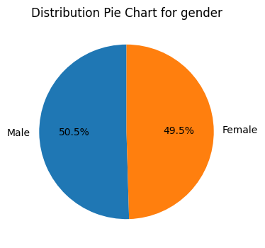

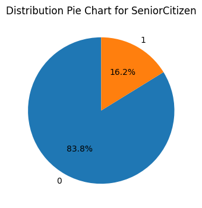

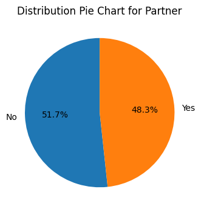

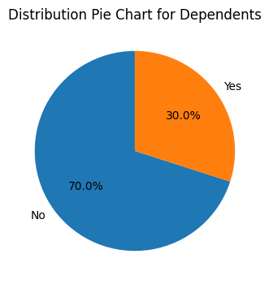

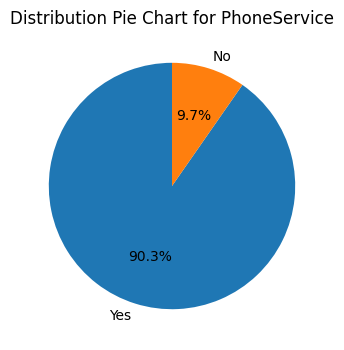

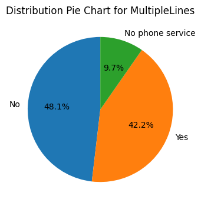

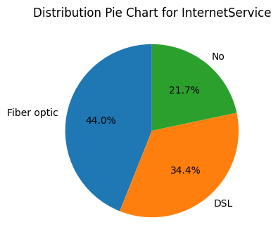

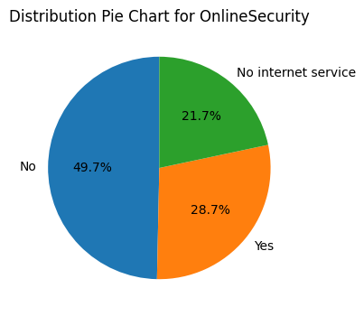

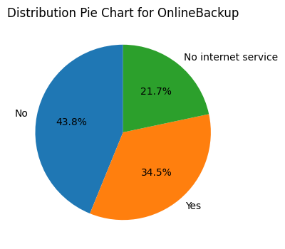

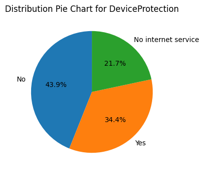

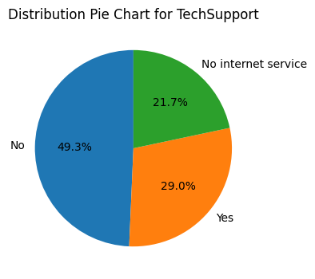

[6 more figures not shown]

```python
distribution_pie_charts(data)
```

**2 d.Share insights for Q2.c**

Lets see the distribution each pie-chart one by one

**1.CustomerID**

- this has so much categories , we are not able to find the distribution properly

**2.gender**

- male has 50.5% of data where as Female has 49.5 % of data
- the data distrubution is near to 50:50 (uniform)

**3.SeniorCitizen**

- 0 has 83.8 % of data and 1 has 16.2 of data
- the data distribution is 8.3 : 1.6 for 0 : 1

**4.Partner** -No has 51.7% of data and yes has 48.3% of data

- the data distrubution is near to 50:50 (uniform)

**5.Dependents**

- No has 70% of data and yes has 30% of data
- No has more data compared to yes
- The distribution - 7:3 for No:Yes

**6.Phone Service**

- Yes has 90.3% of data and No has 9.7% of data
- Yes has more data compared to No
- The distribution - 9 : 0.97 for Yes:No

**7.MultipleLines**

- No has 48.1%of data , Yes has 42.2% of data and No phone service has 9.7% of data
- the size order No > Yes > No phone service
- The data distribution i 4:4:0.9 is No:yes:No Phone service

**8.InternetService**

- fiber optic has 44% of data , DSL has 34.4 % of data and No has 21.7% of data
- The size order fiber optic > DSL > No
- The data distribution - 4:3:2 for Fiber optic : DSL : No

**9.OnlineSecurity**

**10.OnlineBackup**

- No has 43.8% of data, yes has 34.5 % of data and No internet service has 21.7% of data
- The size order No > Yes > no internet service
- the data distribution - 4.3 : 3.4 : 2.1 for No : Yes : No internet service

**11.DeviceProtection**

- No has 43.9% of data, yes has 34.4% of data and No internet service has 21.7% of data
- The size order No>yes>No internet service

**12.TechSupport**

- No has 49.3% of data, Yes has 29% and No internet service 21.7% of data
- The size order No>yes>No internet service
- The data distribution - 4.9 : 2.9 : 2.1 for No : Yes : No internet service

**13.StreamingTV**

- No has 39.9% of data, yes has 38.4 % and No internet service has 21.7%
- The size order No > yes > No internet service
- The data distribution - 3.9 : 3.8 : 2.1 for No : yes : No internet service

**14.StreamingMovies**

- No has 39.55 of data, Yes has 38.8% of data and No internet service has 21.7% of data
- The size order No > Yes > No internet service
- The data distribution - 3.9 : 3.8 : 2.1 for No L yes : No internet service

**15.Contract**

- Month-to-month has 55% of data, Two year has 24.1% of data and One year has 20.9% of data
- The size order Month-to-month > two year > One year
- The data distribution - 5.5 : 2.4 : 2 for Month-to-month : Two year : One year

**16.Paperlessbiling**

- yes has 59.2% of data and no has 40.8% of data
- the size order Yes > No
- the data distribution - 6 : 4 for Yes : No

**17.PaymentMenthod**

- Electronic check has 33.6% of data, Mailed check has 22.9% of data, bank transfer has 21.9% of data and credit card has 21.6% of data
- The size order - electronic check > mailed check > Bank transfer > Credit card
- The data distribution - 3:2:2:2 for electronic check : Mailed check : Bank transfer : Credit card

**18.Churn**

- No has 73.5% of data and Yes has 26.5% of data
- The size order No > yes
- The data distribution - 7.3 : 2.6 for No : yes

**2 e.Encode all the appropriate Categorical features with the best suitable approach**

```python
#removing a CustomerID columns since its not useful
data = data.drop("customerID",axis=1)
```

```python
categorical_columns = data.select_dtypes(include=['object']).columns
categorical_columns
```

```
Index(['gender', 'SeniorCitizen', 'Partner', 'Dependents', 'PhoneService',
       'MultipleLines', 'InternetService', 'OnlineSecurity', 'OnlineBackup',
       'DeviceProtection', 'TechSupport', 'StreamingTV', 'StreamingMovies',
       'Contract', 'PaperlessBilling', 'PaymentMethod', 'Churn'],
      dtype='object')
```

```python
data = pd.get_dummies(data, columns=categorical_columns, drop_first=True)
```

```python
data.head()
```

|  | tenure | MonthlyCharges | TotalCharges | gender_Male | SeniorCitizen_1 | Partner_Yes | Dependents_Yes | PhoneService_Yes | MultipleLines_No phone service | MultipleLines_Yes | ... | StreamingTV_Yes | StreamingMovies_No internet service | StreamingMovies_Yes | Contract_One year | Contract_Two year | PaperlessBilling_Yes | PaymentMethod_Credit card (automatic) | PaymentMethod_Electronic check | PaymentMethod_Mailed check | Churn_Yes |
| --- | --- | --- | --- | --- | --- | --- | --- | --- | --- | --- | --- | --- | --- | --- | --- | --- | --- | --- | --- | --- | --- |
| 0 | 1 | 29.85 | 29.85 | 0 | 0 | 1 | 0 | 0 | 1 | 0 | ... | 0 | 0 | 0 | 0 | 0 | 1 | 0 | 1 | 0 | 0 |
| 1 | 34 | 56.95 | 1889.50 | 1 | 0 | 0 | 0 | 1 | 0 | 0 | ... | 0 | 0 | 0 | 1 | 0 | 0 | 0 | 0 | 1 | 0 |
| 2 | 2 | 53.85 | 108.15 | 1 | 0 | 0 | 0 | 1 | 0 | 0 | ... | 0 | 0 | 0 | 0 | 0 | 1 | 0 | 0 | 1 | 1 |
| 3 | 45 | 42.30 | 1840.75 | 1 | 0 | 0 | 0 | 0 | 1 | 0 | ... | 0 | 0 | 0 | 1 | 0 | 0 | 0 | 0 | 0 | 0 |
| 4 | 2 | 70.70 | 151.65 | 0 | 0 | 0 | 0 | 1 | 0 | 0 | ... | 0 | 0 | 0 | 0 | 0 | 1 | 0 | 1 | 0 | 1 |

5 rows × 31 columns

Encoding for all categorical columns are completed

**2 f.Split the data into 80% train and 20% test.**

```python
X = data.drop('Churn_Yes', axis=1)
y = data['Churn_Yes']
```

```python
X.head()
```

|  | tenure | MonthlyCharges | TotalCharges | gender_Male | SeniorCitizen_1 | Partner_Yes | Dependents_Yes | PhoneService_Yes | MultipleLines_No phone service | MultipleLines_Yes | ... | StreamingTV_No internet service | StreamingTV_Yes | StreamingMovies_No internet service | StreamingMovies_Yes | Contract_One year | Contract_Two year | PaperlessBilling_Yes | PaymentMethod_Credit card (automatic) | PaymentMethod_Electronic check | PaymentMethod_Mailed check |
| --- | --- | --- | --- | --- | --- | --- | --- | --- | --- | --- | --- | --- | --- | --- | --- | --- | --- | --- | --- | --- | --- |
| 0 | 1 | 29.85 | 29.85 | False | False | True | False | False | True | False | ... | False | False | False | False | False | False | True | False | True | False |
| 1 | 34 | 56.95 | 1889.50 | True | False | False | False | True | False | False | ... | False | False | False | False | True | False | False | False | False | True |
| 2 | 2 | 53.85 | 108.15 | True | False | False | False | True | False | False | ... | False | False | False | False | False | False | True | False | False | True |
| 3 | 45 | 42.30 | 1840.75 | True | False | False | False | False | True | False | ... | False | False | False | False | True | False | False | False | False | False |
| 4 | 2 | 70.70 | 151.65 | False | False | False | False | True | False | False | ... | False | False | False | False | False | False | True | False | True | False |

5 rows × 30 columns

```python
y.head()
```

```
0    False
1    False
2     True
3    False
4     True
Name: Churn_Yes, dtype: bool
```

```python
X_train, X_test, y_train, y_test = train_test_split(X, y, test_size=0.2,stratify=y, random_state=42)
```

**2 g.Normalize/Standardize the data with the best suitable approach**

```python
data.info()
```

```
<class 'pandas.core.frame.DataFrame'>
Int64Index: 7043 entries, 0 to 7042
Data columns (total 31 columns):
 #   Column                                 Non-Null Count  Dtype
---  ------                                 --------------  -----
 0   tenure                                 7043 non-null   int64
 1   MonthlyCharges                         7043 non-null   float64
 2   TotalCharges                           7043 non-null   float64
 3   gender_Male                            7043 non-null   uint8
 4   SeniorCitizen_1                        7043 non-null   uint8
 5   Partner_Yes                            7043 non-null   uint8
 6   Dependents_Yes                         7043 non-null   uint8
 7   PhoneService_Yes                       7043 non-null   uint8
 8   MultipleLines_No phone service         7043 non-null   uint8
 9   MultipleLines_Yes                      7043 non-null   uint8
```

[output cut: 23 more lines]

```python
numeric_columns = X.select_dtypes(include=['int64', 'float64']).columns
numeric_columns
```

```
Index(['tenure', 'MonthlyCharges', 'TotalCharges'], dtype='object')
```

```python
scaler = StandardScaler()
X_train[numeric_columns] = scaler.fit_transform(X_train[numeric_columns])
X_test[numeric_columns] = scaler.fit_transform(X_test[numeric_columns])
```

```python
X_train.head()
```

|  | tenure | MonthlyCharges | TotalCharges | gender_Male | SeniorCitizen_1 | Partner_Yes | Dependents_Yes | PhoneService_Yes | MultipleLines_No phone service | MultipleLines_Yes | ... | StreamingTV_No internet service | StreamingTV_Yes | StreamingMovies_No internet service | StreamingMovies_Yes | Contract_One year | Contract_Two year | PaperlessBilling_Yes | PaymentMethod_Credit card (automatic) | PaymentMethod_Electronic check | PaymentMethod_Mailed check |
| --- | --- | --- | --- | --- | --- | --- | --- | --- | --- | --- | --- | --- | --- | --- | --- | --- | --- | --- | --- | --- | --- |
| 3738 | 0.102371 | -0.521976 | -0.263289 | 1 | 0 | 0 | 0 | 0 | 1 | 0 | ... | 0 | 1 | 0 | 1 | 0 | 0 | 0 | 0 | 1 | 0 |
| 3151 | -0.711743 | 0.337478 | -0.504814 | 1 | 0 | 1 | 1 | 1 | 0 | 0 | ... | 0 | 0 | 0 | 0 | 0 | 0 | 0 | 0 | 0 | 1 |
| 4860 | -0.793155 | -0.809013 | -0.751213 | 1 | 0 | 1 | 1 | 0 | 1 | 0 | ... | 0 | 0 | 0 | 0 | 0 | 1 | 0 | 0 | 0 | 1 |
| 3867 | -0.263980 | 0.284384 | -0.173699 | 0 | 0 | 1 | 0 | 1 | 0 | 0 | ... | 0 | 1 | 0 | 1 | 0 | 1 | 1 | 1 | 0 | 0 |
| 3810 | -1.281624 | -0.676279 | -0.990851 | 1 | 0 | 1 | 1 | 1 | 0 | 0 | ... | 0 | 0 | 0 | 0 | 0 | 0 | 0 | 0 | 1 | 0 |

5 rows × 30 columns

```python
X_test.head()
```

|  | tenure | MonthlyCharges | TotalCharges | gender_Male | SeniorCitizen_1 | Partner_Yes | Dependents_Yes | PhoneService_Yes | MultipleLines_No phone service | MultipleLines_Yes | ... | StreamingTV_No internet service | StreamingTV_Yes | StreamingMovies_No internet service | StreamingMovies_Yes | Contract_One year | Contract_Two year | PaperlessBilling_Yes | PaymentMethod_Credit card (automatic) | PaymentMethod_Electronic check | PaymentMethod_Mailed check |
| --- | --- | --- | --- | --- | --- | --- | --- | --- | --- | --- | --- | --- | --- | --- | --- | --- | --- | --- | --- | --- | --- |
| 437 | 1.634958 | 1.671630 | 2.830827 | True | False | True | True | True | False | True | ... | False | True | False | True | False | True | True | True | False | False |
| 2280 | -0.975463 | 1.206555 | -0.585604 | False | True | False | False | True | False | True | ... | False | True | False | True | False | False | True | True | False | False |
| 2235 | 0.370535 | 0.477158 | 0.455032 | False | False | True | True | True | False | True | ... | False | True | False | False | True | False | True | True | False | False |
| 4460 | -0.567585 | 0.472139 | -0.332433 | True | False | True | False | True | False | False | ... | False | False | False | False | False | False | False | False | True | False |
| 3761 | 1.634958 | 0.621030 | 1.678925 | False | False | True | False | True | False | True | ... | False | True | False | True | False | True | True | True | False | False |

5 rows × 30 columns

**3.a Train a model using Decision tree and check the performance of the model on train and test data**

```python
dTree = DecisionTreeClassifier(criterion = 'gini', random_state=1)
dTree.fit(X_train, y_train)
```

```
DecisionTreeClassifier(random_state=1)
```

```python
print("Train Score",dTree.score(X_train, y_train))
print("Test Score",dTree.score(X_test, y_test))
```

```
Train Score 0.9980475683351083
Test Score 0.7352732434350603
```

The simple model has 0.99 as train score and 0.73 as test score

This seems to be overfitted since it perform very good with training set and low with test set

```
Confusion Matrix- Simple Dtree
```

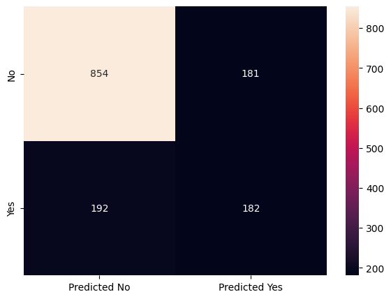

```python
print("Confusion Matrix- Simple Dtree")
y_predict = dTree.predict(X_test)

cm=metrics.confusion_matrix(y_test, y_predict,labels=[0, 1])

df_cm = pd.DataFrame(cm, index = [i for i in ["No","Yes"]],
                  columns = [i for i in ["Predicted No","Predicted Yes"]])
plt.figure(figsize = (7,5))
sns.heatmap(df_cm, annot=True ,fmt='g')
```

```python
predicted_labels_test = dTree.predict(X_test)
print("Test Performance Matrix: (Simple Dtree Model):")
metrics.classification_report(y_test, predicted_labels_test).split("\n")
```

```
Test Performance Matrix: (Simple Dtree Model):
```

```
['              precision    recall  f1-score   support',
 '',
 '       False       0.82      0.83      0.82      1035',
 '        True       0.50      0.49      0.49       374',
 '',
 '    accuracy                           0.74      1409',
 '   macro avg       0.66      0.66      0.66      1409',
 'weighted avg       0.73      0.74      0.73      1409',
 '']
```

**Simple Model Observation**

**Class False:**

Precision is 0.82

Recall is 0.83

F1-Score is 0.822

**Class True:**

Precision is 0.50

Recall is 0.49

F1-Score is 0.49

**3.b Use grid search and improve the performance of the Decision tree model , check the performance of the model on train and test data , provide the differences observed in performance in Q3.a and Q3.b**

```python
param_ = {'criterion':['gini','entropy'],'min_samples_split': [2, 5, 10],'max_depth':[None,5,10,15]}
```

```python
dTreeP = DecisionTreeClassifier( random_state=1)
grid_search = GridSearchCV(estimator=dTreeP, param_grid=param_, cv=5, verbose=True)
grid_search.fit(X_train, y_train)
```

```
Fitting 5 folds for each of 24 candidates, totalling 120 fits
```

```
GridSearchCV(cv=5, estimator=DecisionTreeClassifier(random_state=1),
             param_grid={'criterion': ['gini', 'entropy'],
                         'max_depth': [None, 5, 10, 15],
                         'min_samples_split': [2, 5, 10]},
             verbose=True)
```

```python
dTreeP_model = grid_search.best_estimator_
dTreeP_model
```

```
DecisionTreeClassifier(criterion='entropy', max_depth=5, random_state=1)
```

```python
dTreehp = DecisionTreeClassifier(criterion = 'entropy', max_depth=5, min_samples_leaf=4,random_state=1)
dTreehp.fit(X_train, y_train)
```

```
DecisionTreeClassifier(criterion='entropy', max_depth=5, min_samples_leaf=4,
                       random_state=1)
```

```python
print("Hyper Parametertuning - Train Score",dTreehp.score(X_train, y_train))
print("Hyper Paramtertuning - Test Score",dTreehp.score(X_test, y_test))
```

```
Hyper Parametertuning - Train Score 0.7941072062477813
Hyper Paramtertuning - Test Score 0.7856635911994322
```

**After Hyper Parametr tuning**

**Best Param** criterion = 'entropy'

max_depth = 5

Train Score = 0.79 (reduced from 0.99) Test Score = 0.78 (improved from 0.73)

This ensures the model is not overfitted , it is normalised and so the train score came down and test score improves

```
Confusion Matrix -  HP Dtree
```

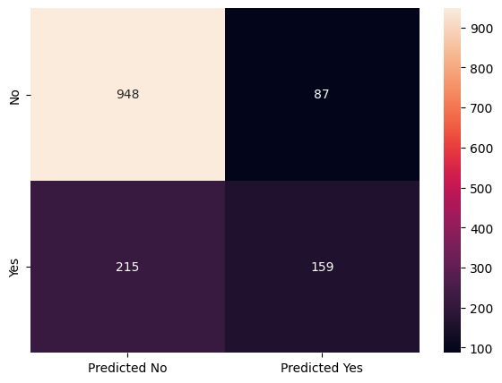

```python
print("Confusion Matrix -  HP Dtree")
y_predict = dTreehp.predict(X_test)

cm=metrics.confusion_matrix(y_test, y_predict,labels=[0, 1])

df_cm = pd.DataFrame(cm, index = [i for i in ["No","Yes"]],
                  columns = [i for i in ["Predicted No","Predicted Yes"]])
plt.figure(figsize = (7,5))
sns.heatmap(df_cm, annot=True ,fmt='g')
```

```python
predicted_labels_test_ = dTreehp.predict(X_test)
print("Test Performance Matrix: (HP Dtree Model):")
metrics.classification_report(y_test, predicted_labels_test_).split("\n")
```

```
Test Performance Matrix: (HP Dtree Model):
```

```
['              precision    recall  f1-score   support',
 '',
 '       False       0.82      0.92      0.86      1035',
 '        True       0.65      0.43      0.51       374',
 '',
 '    accuracy                           0.79      1409',
 '   macro avg       0.73      0.67      0.69      1409',
 'weighted avg       0.77      0.79      0.77      1409',
 '']
```

**HP Dtree Model Observation**

(compared with previous simple model/ non-hp tuned model)

**Class False:**

Precision is 0.82 (same like before)

Recall is 0.92 (improved from 0.83)

F1-Score is 0.86 (improved from 0.82)

**Class True:**

Precision is 0.65 (improved from 0.50)

Recall is 0.43 (reduced from 0.49)

F1-Score is 0.51 (improved from 0.49)

**3.c Train a model using Random forest and check the performance of the model on train and test data**

```python
rfcl = RandomForestClassifier(n_estimators = 50, random_state=1,max_features=10)
rfcl = rfcl.fit(X_train, y_train)
```

```python
print("Random Forest - Train Score",rfcl.score(X_train, y_train))
print("Random Forest - Test Score",rfcl.score(X_test, y_test))
```

```
Random Forest - Train Score 0.9969826056088037
Random Forest - Test Score 0.7792760823278921
```

```
Confusion Matrix - Simple Random Forest
```

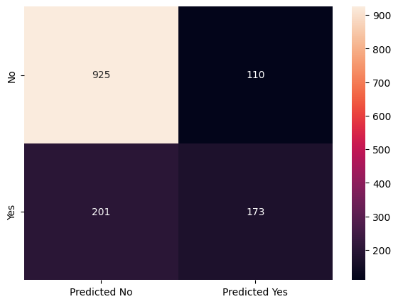

```python
print("Confusion Matrix - Simple Random Forest")
y_predict = rfcl.predict(X_test)

cm=metrics.confusion_matrix(y_test, y_predict,labels=[0, 1])

df_cm = pd.DataFrame(cm, index = [i for i in ["No","Yes"]],
                  columns = [i for i in ["Predicted No","Predicted Yes"]])
plt.figure(figsize = (7,5))
sns.heatmap(df_cm, annot=True ,fmt='g')
```

```python
predicted_labels_test = rfcl.predict(X_test)
print("Test Performance Matrix: (Simple Random Forest Model):")
metrics.classification_report(y_test, predicted_labels_test).split("\n")
```

```
Test Performance Matrix: (Simple Random Forest Model):
```

```
['              precision    recall  f1-score   support',
 '',
 '       False       0.82      0.89      0.86      1035',
 '        True       0.61      0.46      0.53       374',
 '',
 '    accuracy                           0.78      1409',
 '   macro avg       0.72      0.68      0.69      1409',
 'weighted avg       0.77      0.78      0.77      1409',
 '']
```

**Random Forest Model Observation**

**Class False:**

Precision is 0.82

Recall is 0.89

F1-Score is 0.86

**Class True:**

Precision is 0.61

Recall is 0.46

F1-Score is 0.53

**3.d Use grid search and improve the performance of the Random tree model , check the performance of the model on train and test data , provide the differences observed in performance in Q3.c and Q3.d**

```python
param_grid = {
    'n_estimators': [50, 100, 150],
    'max_features': ['sqrt', 'log2', 0.5],
    'max_depth': [None, 10, 20, 30],
    'min_samples_split': [2, 5, 10],
    'min_samples_leaf': [1, 2, 4],
    'bootstrap': [True, False],
    'criterion': ['gini', 'entropy']
}
```

```python
rf = RandomForestClassifier()
grid_search = GridSearchCV(rf, param_grid=param_grid, cv=5, scoring='accuracy', n_jobs=-1)
grid_search.fit(X_train, y_train)
```

```
GridSearchCV(cv=5, estimator=RandomForestClassifier(), n_jobs=-1,
             param_grid={'bootstrap': [True, False],
                         'criterion': ['gini', 'entropy'],
                         'max_depth': [None, 10, 20, 30],
                         'max_features': ['sqrt', 'log2', 0.5],
                         'min_samples_leaf': [1, 2, 4],
                         'min_samples_split': [2, 5, 10],
                         'n_estimators': [50, 100, 150]},
             scoring='accuracy')
```

```python
best_params = grid_search.best_params_
print("Best Parameters:", best_params)
```

```
Best Parameters: {'bootstrap': True, 'criterion': 'gini', 'max_depth': 10, 'max_features': 'log2', 'min_samples_leaf': 1, 'min_samples_split': 5, 'n_estimators': 100}
```

```python
param =   {'bootstrap': True, 'criterion': 'gini', 'max_depth': 10, 'max_features': 'log2', 'min_samples_leaf': 1, 'min_samples_split': 5, 'n_estimators': 100}
```

```python
rfhp = RandomForestClassifier(**param)
rfhp = rfhp.fit(X_train, y_train)
```

```python
print("Random Forest Hyper Parameter - Train Score",rfhp.score(X_train, y_train))
print("Random Forest Hyper Parameter - Test Score",rfhp.score(X_test, y_test))
```

```
Random Forest Hyper Parameter - Train Score 0.8519701810436635
Random Forest Hyper Parameter - Test Score 0.8026969481902059
```

```
Confusion Matrix - HP  Random Forest
```

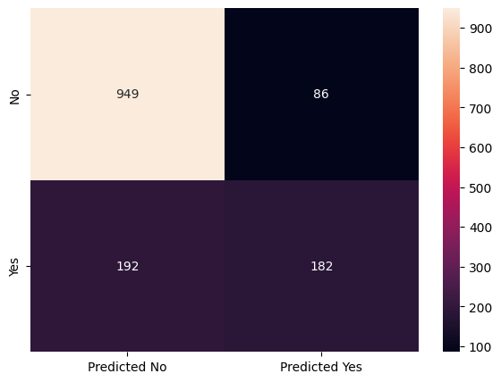

```python
print("Confusion Matrix - HP  Random Forest")
y_predict = rfhp.predict(X_test)

cm=metrics.confusion_matrix(y_test, y_predict,labels=[0, 1])

df_cm = pd.DataFrame(cm, index = [i for i in ["No","Yes"]],
                  columns = [i for i in ["Predicted No","Predicted Yes"]])
plt.figure(figsize = (7,5))
sns.heatmap(df_cm, annot=True ,fmt='g')
```

```python
predicted_labels_test = rfhp.predict(X_test)
print("Test Performance Matrix: (HP Random Forest Model):")
metrics.classification_report(y_test, predicted_labels_test).split("\n")
```

```
Test Performance Matrix: (HP Random Forest Model):
```

```
['              precision    recall  f1-score   support',
 '',
 '       False       0.83      0.92      0.87      1035',
 '        True       0.68      0.49      0.57       374',
 '',
 '    accuracy                           0.80      1409',
 '   macro avg       0.76      0.70      0.72      1409',
 'weighted avg       0.79      0.80      0.79      1409',
 '']
```

**Random Forest HP Model Observation**

(compared with previous simple model/ non-hp tuned model)

Train Score : 0.85 (reduced from 0.99) - Overcomed overfitting from 0.99 Test Score : 0.80 (improved from 0.77) - good normalised prediction

**Class False:**

Precision is 0.83 (increased from 0.82)

Recall is 0.92 (increased from 0.89)

F1-Score is 0.87 (increased from 0.86)

**Class True:**

Precision is 0.68 (increased from 0.61)

Recall is 0.49 (increased from 0.46)

F1-Score is 0.57 (increased from 0.53)

**3.e Train a model using Adaboost and check the performance of the model on train and test data**

```python
abcl = AdaBoostClassifier(n_estimators=10, random_state=1)
abcl = abcl.fit(X_train, y_train)
```

```python
print("Ada Boosting - Train Score",abcl.score(X_train, y_train))
print("Ada Boosting - Test Score",abcl.score(X_test, y_test))
```

```
Ada Boosting - Train Score 0.7946396876109336
Ada Boosting - Test Score 0.7877927608232789
```

```
Confusion Matrix - Simple Ada Boosting
```

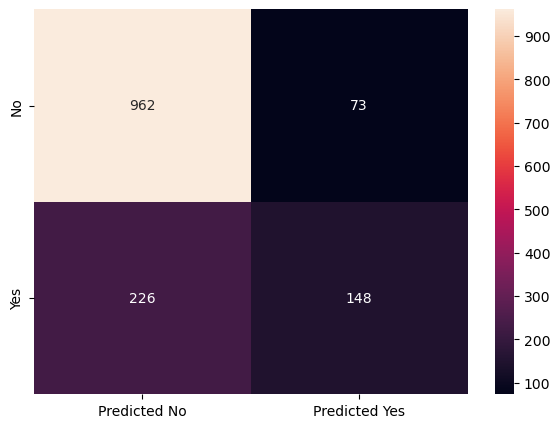

```python
print("Confusion Matrix - Simple Ada Boosting")
y_predict = abcl.predict(X_test)

cm=metrics.confusion_matrix(y_test, y_predict,labels=[0, 1])

df_cm = pd.DataFrame(cm, index = [i for i in ["No","Yes"]],
                  columns = [i for i in ["Predicted No","Predicted Yes"]])
plt.figure(figsize = (7,5))
sns.heatmap(df_cm, annot=True ,fmt='g')
```

```python
predicted_labels_test = abcl.predict(X_test)
print("Test Performance Matrix: (Simple Ada Boosting Model):")
metrics.classification_report(y_test, predicted_labels_test).split("\n")
```

```
Test Performance Matrix: (Simple Ada Boosting Model):
```

```
['              precision    recall  f1-score   support',
 '',
 '           0       0.81      0.93      0.87      1035',
 '           1       0.67      0.40      0.50       374',
 '',
 '    accuracy                           0.79      1409',
 '   macro avg       0.74      0.66      0.68      1409',
 'weighted avg       0.77      0.79      0.77      1409',
 '']
```

**Adaboosting Model Observation**

Train Score : 0.79

Test Score : 0.78

**Class False:**

Precision is 0.81

Recall is 0.93

F1-Score is 0.87

**Class True:**

Precision is 0.67

Recall is 0.40

F1-Score is 0.50

**3.f Use grid search and improve the performance of the Adaboost model , check the performance of the model on train and test data , provide the differences observed in performance in Q3.e and Q3.f**

```python
param_grid = {
    'n_estimators': [50, 100],
    'learning_rate': [0.01, 0.1, 1.0],
    'algorithm': ['SAMME', 'SAMME.R']
}
```

```python
adaboost = AdaBoostClassifier()
grid_search = GridSearchCV(adaboost, param_grid=param_grid, cv=5, scoring='accuracy', n_jobs=-1)
grid_search.fit(X_train, y_train)
```

```
GridSearchCV(cv=5, estimator=AdaBoostClassifier(), n_jobs=-1,
             param_grid={'algorithm': ['SAMME', 'SAMME.R'],
                         'learning_rate': [0.01, 0.1, 1.0],
                         'n_estimators': [50, 100]},
             scoring='accuracy')
```

```python
best_params = grid_search.best_params_
print("Best Parameters: of Ada Boosting (Hyper parameter tuned)", best_params)
```

```
Best Parameters: of Ada Boosting (Hyper parameter tuned) {'algorithm': 'SAMME.R', 'learning_rate': 1.0, 'n_estimators': 100}
```

```python
abhp = AdaBoostClassifier(**best_params, random_state=1)
abhp = abhp.fit(X_train, y_train)
```

```python
print("Ada Boosting HP(Grid search) - Train Score",abhp.score(X_train, y_train))
print("Ada Boosting HP(Grid search)- Test Score",abhp.score(X_test, y_test))
```

```
Ada Boosting HP(Grid search) - Train Score 0.8136315228966986
Ada Boosting HP(Grid search)- Test Score 0.7955997161107168
```

```python
print("Confusion Matrix - Simple Ada Boosting")
y_predict = abhp.predict(X_test)

cm=metrics.confusion_matrix(y_test, y_predict,labels=[0, 1])

df_cm = pd.DataFrame(cm, index = [i for i in ["No","Yes"]],
                  columns = [i for i in ["Predicted No","Predicted Yes"]])
plt.figure(figsize = (7,5))
sns.heatmap(df_cm, annot=True ,fmt='g')
```

[output not shown]

```python
predicted_labels_test = abhp.predict(X_test)
print("Test Performance Matrix: (HP Ada boosting Model):")
metrics.classification_report(y_test, predicted_labels_test).split("\n")
```

```
Test Performance Matrix: (HP Ada boosting Model):
```

```
['              precision    recall  f1-score   support',
 '',
 '           0       0.83      0.91      0.87      1035',
 '           1       0.66      0.48      0.55       374',
 '',
 '    accuracy                           0.80      1409',
 '   macro avg       0.74      0.69      0.71      1409',
 'weighted avg       0.78      0.80      0.78      1409',
 '']
```

**Adaboosting Model HP (Grid Search) Observation**

(compared with previous simple model/ non-hp tuned model)

Train Score : 0.81(improved from 0.79)

Test Score : 0.79(improved from 0.78)

**Class False:**

Precision is 0.83(improved from 0.81)

**Class True:**

Precision is 0.66(reduced from 0.67)

Recall is 0.48(improved from 0.40)

F1-Score is 0.55(improved from 0.50)

**3.g Train a model using GradientBoost and check the performance of the model on train and test data**

```python
gbcl = GradientBoostingClassifier(n_estimators = 50,random_state=1)
gbcl = gbcl.fit(X_train, y_train)
```

```python
print("Gradient Boosting - Train Score",gbcl.score(X_train, y_train))
print("Gradient Boosting - Test Score",gbcl.score(X_test, y_test))
```

```
Gradient Boosting - Train Score 0.8162939297124601
Gradient Boosting - Test Score 0.794889992902768
```

```
Confusion Matrix - Simple Gradient Boosting
```

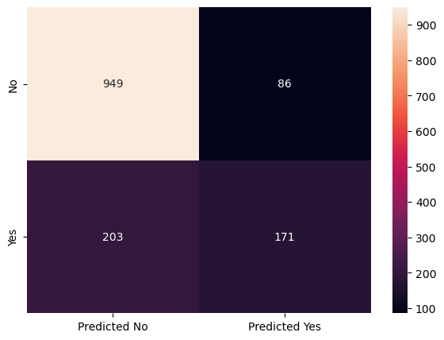

```python
print("Confusion Matrix - Simple Gradient Boosting")
y_predict = gbcl.predict(X_test)

cm=metrics.confusion_matrix(y_test, y_predict,labels=[0, 1])

df_cm = pd.DataFrame(cm, index = [i for i in ["No","Yes"]],
                  columns = [i for i in ["Predicted No","Predicted Yes"]])
plt.figure(figsize = (7,5))
sns.heatmap(df_cm, annot=True ,fmt='g')
```

```python
predicted_labels_test = gbcl.predict(X_test)
print("Test Performance Matrix: (Simple Gradient Boosting Model):")
metrics.classification_report(y_test, predicted_labels_test).split("\n")
```

```
Test Performance Matrix: (Simple Gradient Boosting Model):
```

```
['              precision    recall  f1-score   support',
 '',
 '           0       0.82      0.92      0.87      1035',
 '           1       0.67      0.46      0.54       374',
 '',
 '    accuracy                           0.79      1409',
 '   macro avg       0.74      0.69      0.70      1409',
 'weighted avg       0.78      0.79      0.78      1409',
 '']
```

**Gradient Model Observation**

Train Score : 0.81

Test Score : 0.79

**Class False:**

Precision is 0.82

Recall is 0.92

F1-Score is 0.87

**Class True:**

Precision is 0.67

Recall is 0.46

**3.h Use grid search and improve the performance of the GradientBoost model , check the performance of the model on train and test data , provide the differences observed in performance in Q3.g and Q3.h**

```python
param_grid = {
    'n_estimators': [50, 100,150,200],
    'learning_rate': [0.01, 0.1, 0.2],
    'max_depth': [3, 4, 5],
    'min_samples_split': [2, 5, 10],
    'min_samples_leaf': [1, 2, 4],
    'subsample': [0.8, 1.0]
    }
```

```python
gradient_boost = GradientBoostingClassifier()
grid_search = GridSearchCV(gradient_boost, param_grid=param_grid, cv=5, scoring='accuracy', n_jobs=10)
grid_search.fit(X_train, y_train)
```

```
GridSearchCV(cv=5, estimator=GradientBoostingClassifier(), n_jobs=10,
             param_grid={'learning_rate': [0.01, 0.1, 0.2],
                         'max_depth': [3, 4, 5], 'min_samples_leaf': [1, 2, 4],
                         'min_samples_split': [2, 5, 10],
                         'n_estimators': [50, 100, 150, 200],
                         'subsample': [0.8, 1.0]},
             scoring='accuracy')
```

```python
best_params_g = grid_search.best_params_
print("Best Parameters: Gradient Boosting ", best_params_g)
```

```
Best Parameters: Gradient Boosting  {'learning_rate': 0.1, 'max_depth': 3, 'min_samples_leaf': 2, 'min_samples_split': 2, 'n_estimators': 50, 'subsample': 0.8}
```

```python
gbhp = GradientBoostingClassifier(**best_params_g,random_state=1)
gbhp = gbhp.fit(X_train, y_train)
```

```python
print("Gradient Boosting HP(used grid search) - Train Score",gbhp.score(X_train, y_train))
print("Gradient Boosting HP(used grid search) - Test Score",gbhp.score(X_test, y_test))
```

```
Gradient Boosting HP(used grid search) - Train Score 0.8189563365282215
Gradient Boosting HP(used grid search) - Test Score 0.794889992902768
```

```
Confusion Matrix - HP Gradient Boosting
```

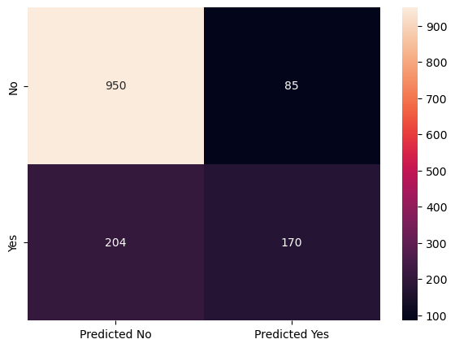

```python
print("Confusion Matrix - HP Gradient Boosting")
y_predict = gbhp.predict(X_test)

cm=metrics.confusion_matrix(y_test, y_predict,labels=[0, 1])

df_cm = pd.DataFrame(cm, index = [i for i in ["No","Yes"]],
                  columns = [i for i in ["Predicted No","Predicted Yes"]])
plt.figure(figsize = (7,5))
sns.heatmap(df_cm, annot=True ,fmt='g')
```

```python
predicted_labels_test = gbhp.predict(X_test)
print("Test Performance Matrix: (HP Gradient Boosting Model):")
metrics.classification_report(y_test, predicted_labels_test).split("\n")
```

[output not shown]

**Gradient Model HP (used Grid Search for Hyperparameter tuning) Observation** (Compared with previous simple non-HP tuned/simple model)

Train Score : 0.81 (same)

Test Score : 0.79 (same)

**Class False:**

Recall is 0.92 (same)

F1-Score is 0.87 (same)

**Class True:**

**3.i Provide detailed analysis of the below steps**

I )Compare the performance of each model in train stage and test stage

II ) Provide your observation on which model performed the best

III )Provide your reasoning on why the model performed best iv )Provide your final conclusion on your observation

[figure not shown]

**Observation on which model performed the best**

Based on the observation, Hyper paramter tuned Random Forest is the best model which has generalised train score of 0.85 (without overfitting) and performs very good with testing data with testing score of 0.80 (highest of all other model) with good values for precision, recall and f1 metrics compared to other models

class 0

Precision - 0.83 Recall - 0.92 F1 - 0.87

class 1

Precision - 0.68 Recall - 0.49 F1 - 0.57

**Reasoning on why the model performed best** By adjusting the model's parameters to the unique features of the dataset, hyperparameter tuning frequently improves model performance. In general, Random Forest models exhibit robustness and good performance on a variety of data types. A more ideal arrangement most certainly helped the hyperparameter-tuned Random Forest model perform better.

**Final conclusion on your observation** A key factor in the model's ability to identify patterns in the data is the Random Forest algorithm selection and hyperparameter adjustment.

Remember that selecting the "best" model could rely on the particular objectives of the application. The relevance of various metrics (such as accuracy, precision, recall, etc.) varies based on the problem's context. As a result, the final decision should take the application's limitations and unique requirements into account.